# A Proportions Model for Powerlifting

Andrés De Freitas Carmona

2025-01-06

# Modelling Through Proportions: A Case Study for Powerlifting

In the descriptive analysis of this project, it was mentioned the competitions with only **one movement** (competitions with two movements do not exist under the IPF) would be removed from the data set. This document justifies that decision.

The current project’s purpose was to test the following hypothesis: the majority of athletes who reach podiums are **Deadlift Specialists**. To do so, some questions had to be answered first:

1. What is a **Deadlift**?

In *Powerlifting*, there are three movements: **Squat**, **Bench Press** and **Deadlift**. Each movement has three attempts, with the highest weight in the three attempts recorded, which adds to the total weight lifted by an athlete in the three movements.

2. What is a **Deadlift Specialist**?

Every sport contains specific qualities required to perform well in it, and *Powerlifting* is not an exception. All three movements are different from each other, and while athletes may overall perform decently in each movement, almost everyone has a movement they execute better than the others. For those who have a clear bias towards a movement, they are called **movement specialists**.

Movement specialists can be explained by multiple factors. One in particular is relevant: **biomechanics**, which is the study of how external and internal forces affect the human body. How does **biomechanics** influence athletes in *Powerlifting*? Imagine two athletes with the exact same height, but one has long torso in comparison to their legs, and the other long legs in relation to its torso. These differences in body leverages have a significant impact in the performance of athletes in each movement. The anatomical characteristics that explain a better performance in one of the three movements are also the ones that explain a decrease in the performance of others.

Federations do not collect data regarding the **biomechanics** of each athlete. To define **movement specialists**, another set of criteria must be followed.

# 1. Libraries

```r
library(readr)
library(dplyr)
library(lubridate)
library(ggplot2)
library(tidyr)
```

# 2. Data loading

The data was downloaded from openpowerlifting.org on January 4th, 2025.

```r
openpowerliftingdata <- read_csv("C:/Users/andre/OneDrive/Escritorio/TFM/openpowerliftingdata3.csv")
```

# 3. Data division

1. Data is split in female and male data sets, allowing for better data management.
2. Data has been filtered for the International Powerlifting Federation (IPF), one of the most important federations in the sport.

```r
ipf_male_data <- openpowerliftingdata %>% filter(Federation == "IPF", Sex == "M")
ipf_female_data <- openpowerliftingdata %>% filter(Federation == "IPF", Sex == "F")
```

# 4. Data cleaning

### 4.1. Convert variables to factors.

```r
ipf_male_data <- ipf_male_data %>%
  mutate(
    WeightClassKg = as.factor(WeightClassKg),
    Division = as.factor(Division),
    Equipment = as.factor(Equipment)
  )

ipf_female_data <- ipf_female_data %>%
  mutate(
    WeightClassKg = as.factor(WeightClassKg),
    Division = as.factor(Division),
    Equipment = as.factor(Equipment)
  )
```

### 4.2. Classifying competitions by movements.

Not all competitions host all three movements in their events. There are either one or three movement competitions.

```r
# Male

ipf_male_data <- ipf_male_data %>%
  mutate(
    BooleanSquat = ifelse(
      is.na(Bench1Kg) & is.na(Bench2Kg) & is.na(Bench3Kg) & is.na(Bench4Kg) & is.na(Best3BenchKg) &
        is.na(Deadlift1Kg) & is.na(Deadlift2Kg) & is.na(Deadlift3Kg) & is.na(Deadlift4Kg) & is.na(Best3DeadliftKg) &
        (!is.na(Squat1Kg) | !is.na(Squat2Kg) | !is.na(Squat3Kg) | !is.na(Squat4Kg) | !is.na(Best3SquatKg)),
      1, 0
    ),
    BooleanBench = ifelse(
      is.na(Squat1Kg) & is.na(Squat2Kg) & is.na(Squat3Kg) & is.na(Squat4Kg) & is.na(Best3SquatKg) &
        is.na(Deadlift1Kg) & is.na(Deadlift2Kg) & is.na(Deadlift3Kg) & is.na(Deadlift4Kg) & is.na(Best3DeadliftKg) &
        (!is.na(Bench1Kg) | !is.na(Bench2Kg) | !is.na(Bench3Kg) | !is.na(Bench4Kg) | !is.na(Best3BenchKg)),
      1, 0
    ),
    BooleanDeadlift = ifelse(
      is.na(Squat1Kg) & is.na(Squat2Kg) & is.na(Squat3Kg) & is.na(Squat4Kg) & is.na(Best3SquatKg) &
        is.na(Bench1Kg) & is.na(Bench2Kg) & is.na(Bench3Kg) & is.na(Bench4Kg) & is.na(Best3BenchKg) &
        (!is.na(Deadlift1Kg) | !is.na(Deadlift2Kg) | !is.na(Deadlift3Kg) | !is.na(Deadlift4Kg) | !is.na(Best3DeadliftKg)),
      1, 0
    ),
    BooleanDisq = ifelse(
      (is.na(Squat1Kg) & is.na(Squat2Kg) & is.na(Squat3Kg) & is.na(Squat4Kg) & is.na(Best3SquatKg) &
         is.na(Bench1Kg) & is.na(Bench2Kg) & is.na(Bench3Kg) & is.na(Bench4Kg) & is.na(Best3BenchKg) &
         is.na(Deadlift1Kg) & is.na(Deadlift2Kg) & is.na(Deadlift3Kg) & is.na(Deadlift4Kg) & is.na(Best3DeadliftKg)) |
        Place == "DQ",
      1, 0
    )
  )

# Female

ipf_female_data <- ipf_female_data %>%
  mutate(
    BooleanSquat = ifelse(
      is.na(Bench1Kg) & is.na(Bench2Kg) & is.na(Bench3Kg) & is.na(Bench4Kg) & is.na(Best3BenchKg) &
        is.na(Deadlift1Kg) & is.na(Deadlift2Kg) & is.na(Deadlift3Kg) & is.na(Deadlift4Kg) & is.na(Best3DeadliftKg) &
        (!is.na(Squat1Kg) | !is.na(Squat2Kg) | !is.na(Squat3Kg) | !is.na(Squat4Kg) | !is.na(Best3SquatKg)),
      1, 0
    ),
    BooleanBench = ifelse(
      is.na(Squat1Kg) & is.na(Squat2Kg) & is.na(Squat3Kg) & is.na(Squat4Kg) & is.na(Best3SquatKg) &
        is.na(Deadlift1Kg) & is.na(Deadlift2Kg) & is.na(Deadlift3Kg) & is.na(Deadlift4Kg) & is.na(Best3DeadliftKg) &
        (!is.na(Bench1Kg) | !is.na(Bench2Kg) | !is.na(Bench3Kg) | !is.na(Bench4Kg) | !is.na(Best3BenchKg)),
      1, 0
    ),
    BooleanDeadlift = ifelse(
      is.na(Squat1Kg) & is.na(Squat2Kg) & is.na(Squat3Kg) & is.na(Squat4Kg) & is.na(Best3SquatKg) &
        is.na(Bench1Kg) & is.na(Bench2Kg) & is.na(Bench3Kg) & is.na(Bench4Kg) & is.na(Best3BenchKg) &
        (!is.na(Deadlift1Kg) | !is.na(Deadlift2Kg) | !is.na(Deadlift3Kg) | !is.na(Deadlift4Kg) | !is.na(Best3DeadliftKg)),
      1, 0
    ),
    BooleanDisq = ifelse(
      (is.na(Squat1Kg) & is.na(Squat2Kg) & is.na(Squat3Kg) & is.na(Squat4Kg) & is.na(Best3SquatKg) &
         is.na(Bench1Kg) & is.na(Bench2Kg) & is.na(Bench3Kg) & is.na(Bench4Kg) & is.na(Best3BenchKg) &
         is.na(Deadlift1Kg) & is.na(Deadlift2Kg) & is.na(Deadlift3Kg) & is.na(Deadlift4Kg) & is.na(Best3DeadliftKg)) |
        Place == "DQ",
      1, 0
    )
  )
```

### 4.3. Removing competitions with only one movement.

```r
# Male

ipf_male_data_clean <- ipf_male_data %>%
  filter(
    (BooleanSquat + BooleanBench + BooleanDeadlift != 1) &
      (BooleanDisq == 0)
  )

# Female

ipf_female_data_clean <- ipf_female_data %>%
  filter(
    (BooleanSquat + BooleanBench + BooleanDeadlift != 1) &
      (BooleanDisq == 0)
  )
```

### 4.4. Removing boolean variables created, since they no longer serve any purpose.

```r
ipf_male_data_clean <- ipf_male_data_clean %>%
  select(-BooleanSquat, -BooleanBench, -BooleanDeadlift, -BooleanDisq)

ipf_female_data_clean <- ipf_female_data_clean %>%
  select(-BooleanSquat, -BooleanBench, -BooleanDeadlift, -BooleanDisq)
```

### 4.5. Removing old divisions.

**Divisions** evolved through time. Nowadays, the IPF ceased the use of the following.

```r
excluded_divisions <- c("Light", "Middle", "Heavy", "Super", "SOI", "SuperHeavy")

ipf_male_data_clean <- ipf_male_data_clean %>%
  filter(!Division %in% excluded_divisions)

ipf_female_data_clean <- ipf_female_data_clean %>%
  filter(!Division %in% excluded_divisions)
```

### 4.6. Removing disqualified athletes.

```r
excluded_places <- c("DD", "DQ", "G")

ipf_male_data_clean <- ipf_male_data_clean %>%
  filter(!Place %in% excluded_places)

ipf_female_data_clean <- ipf_female_data_clean %>%
  filter(!Place %in% excluded_places)
```

# 5. Proportions Model

Data related to **biomechanics** might not be available, but what it is present in the data set is the best attempts of each movement. One movement’s lifted weight represents a proportion of the total weight lifted by an athlete in a competition. From a statistical point of view, proportions could be a criterion to classify movement specialists.

### 5.1. Proportion variables.

We create new variables to calculate the individual proportions of each movement respect to the total for each athlete.

```r
ipf_male_data_clean <- ipf_male_data_clean %>%
  mutate(
    SquatProportion = Best3SquatKg / TotalKg,
    BenchPressProportion = Best3BenchKg / TotalKg,
    DeadliftProportion = Best3DeadliftKg / TotalKg
  )


ipf_female_data_clean <- ipf_female_data_clean %>%
  mutate(
    SquatProportion = Best3SquatKg / TotalKg,
    BenchPressProportion = Best3BenchKg / TotalKg,
    DeadliftProportion = Best3DeadliftKg / TotalKg
  )

# Some of the values in the proportions are not available. Instead of removing this rows, we could fill them with values to optimize the use of data.
# First, we verify NA values are statistically insignificant compared to the data.

# Hypothesis contrast

# H0: Proportion of rows with NA values = 0
# HA: Proportion of rows with NA values > 0

total_rows_male <- nrow(ipf_male_data_clean)
total_rows_female <- nrow(ipf_female_data_clean)

na_rows_male <- sum(is.na(ipf_male_data_clean$SquatProportion) |
                      is.na(ipf_male_data_clean$BenchPressProportion) |
                      is.na(ipf_male_data_clean$DeadliftProportion))

na_rows_female <- sum(is.na(ipf_female_data_clean$SquatProportion) |
                        is.na(ipf_female_data_clean$BenchPressProportion) |
                        is.na(ipf_female_data_clean$DeadliftProportion))

proportion_na_male <- na_rows_male / total_rows_male
proportion_na_female <- na_rows_female / total_rows_female

cat("Proportion of rows with NA values (Male):", proportion_na_male, "\n")
```

```
## Proportion of rows with NA values (Male): 9.538344e-05
```

```r
cat("Proportion of rows with NA values (Female):", proportion_na_female, "\n")
```

```
## Proportion of rows with NA values (Female): 0
```

```r
binom_test_male <- binom.test(na_rows_male, total_rows_male, p = 0)
binom_test_female <- binom.test(na_rows_female, total_rows_female, p = 0)

cat("Binomial test for NA proportion (Male):\n")
```

```
## Binomial test for NA proportion (Male):
```

```r
print(binom_test_male)
```

```
##
##  Exact binomial test
##
## data:  na_rows_male and total_rows_male
## number of successes = 2, number of trials = 20968, p-value < 2.2e-16
## alternative hypothesis: true probability of success is not equal to 0
## 95 percent confidence interval:
##  1.155159e-05 3.445149e-04
## sample estimates:
## probability of success
##           9.538344e-05
```

```r
cat("\nBinomial test for NA proportion (Female):\n")
```

```
##
## Binomial test for NA proportion (Female):
```

```r
print(binom_test_female)
```

[output not shown]

```r
# Bootstrap test

set.seed(123)

calculate_na_proportion <- function(data, total_rows) {
  na_rows <- data %>%
    filter(is.na(SquatProportion) | is.na(BenchPressProportion) | is.na(DeadliftProportion)) %>%
    nrow()
  return(na_rows / total_rows)
}

n_bootstrap <- 1000

male_na_proportions <- numeric(n_bootstrap)
female_na_proportions <- numeric(n_bootstrap)

for (i in 1:n_bootstrap) {

  male_sample <- ipf_male_data_clean %>% sample_frac(replace = TRUE)
  female_sample <- ipf_female_data_clean %>% sample_frac(replace = TRUE)


  male_na_proportions[i] <- calculate_na_proportion(male_sample, nrow(male_sample))
  female_na_proportions[i] <- calculate_na_proportion(female_sample, nrow(female_sample))
}

male_ci <- quantile(male_na_proportions, c(0.025, 0.975))
female_ci <- quantile(female_na_proportions, c(0.025, 0.975))

cat("95% CI for proportion of NA values (Male):", male_ci, "\n")
```

```
## 95% CI for proportion of NA values (Male): 0 0.0002384586
```

```r
cat("95% CI for proportion of NA values (Female):", female_ci, "\n")
```

```
## 95% CI for proportion of NA values (Female): 0 0
```

```r
# Conclusion: Statistically and practically, NA values represent an insignificant amount of the data.
```

### 5.2. Synthetic data applied.

Data will be filled with the average values of the proportions, since the data has a normal distribution.

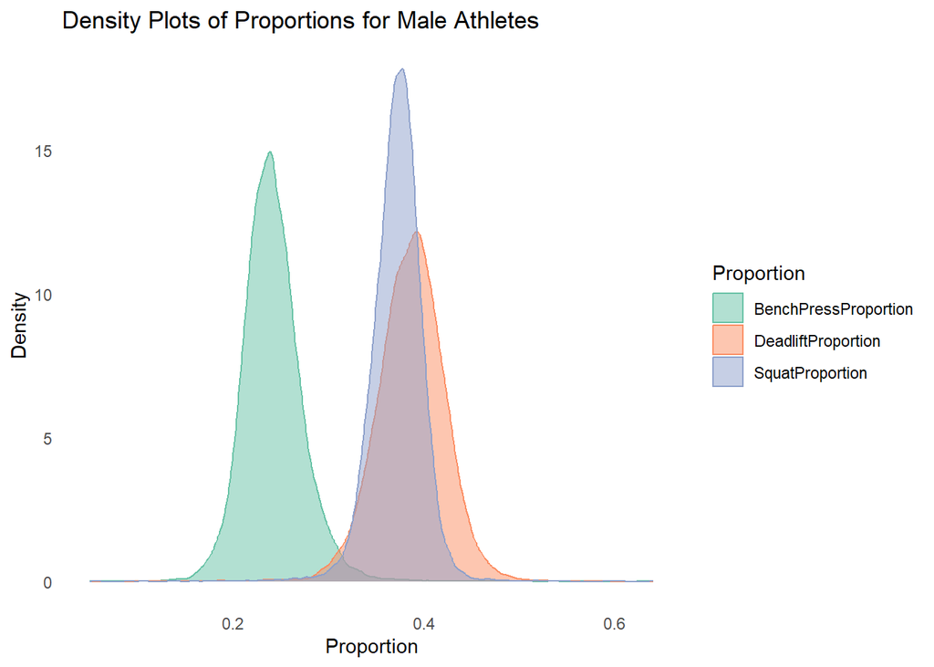

```r
# Male proportions distribution

male_proportions_long <- ipf_male_data_clean %>%
  select(SquatProportion, BenchPressProportion, DeadliftProportion) %>%
  pivot_longer(cols = everything(), names_to = "Proportion", values_to = "Value")

ggplot(male_proportions_long, aes(x = Value, fill = Proportion, color = Proportion)) +
  geom_density(alpha = 0.5) +
  labs(title = "Density Plots of Proportions for Male Athletes",
       x = "Proportion",
       y = "Density") +
  theme_minimal() +
  scale_fill_brewer(palette = "Set2") +
  scale_color_brewer(palette = "Set2") +
  theme(
    panel.grid = element_blank(),
  )
```

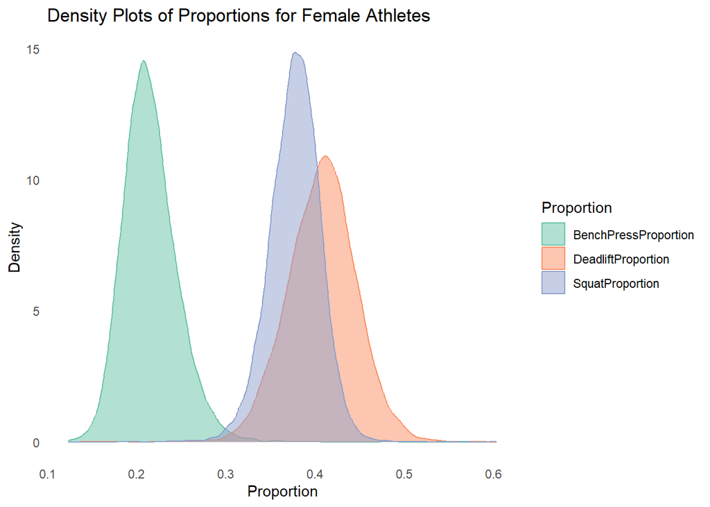

```r
# Female proportions distribution

female_proportions_long <- ipf_female_data_clean %>%
  select(SquatProportion, BenchPressProportion, DeadliftProportion) %>%
  pivot_longer(cols = everything(), names_to = "Proportion", values_to = "Value")

ggplot(female_proportions_long, aes(x = Value, fill = Proportion, color = Proportion)) +
  geom_density(alpha = 0.5) +
  labs(title = "Density Plots of Proportions for Female Athletes",
       x = "Proportion",
       y = "Density") +
  theme_minimal() +
  scale_fill_brewer(palette = "Set2") +
  scale_color_brewer(palette = "Set2") +
  theme(
    panel.grid = element_blank(),
  )
```

### 5.3. Averages normalization.

Proportions must be normalized, since the sum of averages can be different from 1.

```r
# Normalized proportions

# Male

ipf_male_data_clean <- ipf_male_data_clean %>%
  mutate(
    SquatProportion = ifelse(is.na(SquatProportion), mean(SquatProportion, na.rm = TRUE), SquatProportion),
    BenchPressProportion = ifelse(is.na(BenchPressProportion), mean(BenchPressProportion, na.rm = TRUE), BenchPressProportion),
    DeadliftProportion = ifelse(is.na(DeadliftProportion), mean(DeadliftProportion, na.rm = TRUE), DeadliftProportion)
  ) %>%
  mutate(
    TotalProportion = SquatProportion + BenchPressProportion + DeadliftProportion,
    SquatProportion = SquatProportion / TotalProportion,
    BenchPressProportion = BenchPressProportion / TotalProportion,
    DeadliftProportion = DeadliftProportion / TotalProportion
  ) %>%
  select(-TotalProportion)


# Female

ipf_female_data_clean <- ipf_female_data_clean %>%
  mutate(
    SquatProportion = ifelse(is.na(SquatProportion), mean(SquatProportion, na.rm = TRUE), SquatProportion),
    BenchPressProportion = ifelse(is.na(BenchPressProportion), mean(BenchPressProportion, na.rm = TRUE), BenchPressProportion),
    DeadliftProportion = ifelse(is.na(DeadliftProportion), mean(DeadliftProportion, na.rm = TRUE), DeadliftProportion)
  ) %>%
  mutate(
    TotalProportion = SquatProportion + BenchPressProportion + DeadliftProportion,
    SquatProportion = SquatProportion / TotalProportion,
    BenchPressProportion = BenchPressProportion / TotalProportion,
    DeadliftProportion = DeadliftProportion / TotalProportion
  ) %>%
  select(-TotalProportion)
```

### 5.4. Checking normalization.

Checking if proportions were normalized correctly.

```r
ipf_male_data_clean <- ipf_male_data_clean %>%
  mutate(
    ProportionsSum = SquatProportion + BenchPressProportion + DeadliftProportion,
    IsProportionsEqualToOne = ifelse(abs(ProportionsSum - 1) < 1e-6, TRUE, FALSE)
  ) %>%
  select(-ProportionsSum, -IsProportionsEqualToOne)

ipf_female_data_clean <- ipf_female_data_clean %>%
  mutate(
    ProportionsSum = SquatProportion + BenchPressProportion + DeadliftProportion,
    IsProportionsEqualToOne = ifelse(abs(ProportionsSum - 1) < 1e-6, TRUE, FALSE)
  ) %>%
  select(-ProportionsSum, -IsProportionsEqualToOne)
```

### 5.5. Correlation matrix for the proportions between the three movements.

Movement proportions correlate negatively, particularly with deadlift combinations.

```r
correlation_matrix_male <- ipf_male_data_clean %>%
  select(SquatProportion, BenchPressProportion, DeadliftProportion) %>%
  cor()

correlation_matrix_female <- ipf_female_data_clean %>%
  select(SquatProportion, BenchPressProportion, DeadliftProportion) %>%
  cor()

print(correlation_matrix_female)
```

```
##                      SquatProportion BenchPressProportion DeadliftProportion
## SquatProportion            1.0000000           -0.1380464         -0.6276575
## BenchPressProportion      -0.1380464            1.0000000         -0.6843903
## DeadliftProportion        -0.6276575           -0.6843903          1.0000000
```

```r
print(correlation_matrix_male)
```

```
##                      SquatProportion BenchPressProportion DeadliftProportion
## SquatProportion            1.0000000           -0.2411180         -0.5186126
## BenchPressProportion      -0.2411180            1.0000000         -0.7047361
## DeadliftProportion        -0.5186126           -0.7047361          1.0000000
```

### 5.6. Average proportions and standard deviations by weight class, division, equipment, sex, competition and year.

After individual proportions have been calculated, group averages are next. In this case, group averages will be calculated by:

- Weight class
- Division
- Equipment
- Sex
- MeetName
- Date

Each weight class, from each division, equipment, sex, competition and year, has different averages in their proportions. For example, as records keep improving, a competition from 2008 may have different averages to the competitions from 2024.

```r
# Male

average_proportions_male <- ipf_male_data_clean %>%
  group_by(WeightClassKg, Division, Equipment, Sex, MeetName, Date) %>%
  summarize(
    AvgSquatProportion = mean(SquatProportion, na.rm = TRUE),
    AvgBenchPressProportion = mean(BenchPressProportion, na.rm = TRUE),
    AvgDeadliftProportion = mean(DeadliftProportion, na.rm = TRUE),
    StandDevSquat = sd(SquatProportion, na.rm = TRUE),
    StandDevBench = sd(BenchPressProportion, na.rm = TRUE),
    StandDevDeadlift = sd(DeadliftProportion, na.rm = TRUE)
  )


# Female

average_proportions_female <- ipf_female_data_clean %>%
  group_by(WeightClassKg, Division, Equipment, Sex, MeetName, Date) %>%
  summarize(
    AvgSquatProportion = mean(SquatProportion, na.rm = TRUE),
    AvgBenchPressProportion = mean(BenchPressProportion, na.rm = TRUE),
    AvgDeadliftProportion = mean(DeadliftProportion, na.rm = TRUE),
    StandDevSquat = sd(SquatProportion, na.rm = TRUE),
    StandDevBench = sd(BenchPressProportion, na.rm = TRUE),
    StandDevDeadlift = sd(DeadliftProportion, na.rm = TRUE)
  )
```

### 5.7. Data transferring.

Transferring average proportions and standard deviations to the datasets.

```r
ipf_male_data_clean <- ipf_male_data_clean %>%
  left_join(average_proportions_male, by = c("WeightClassKg", "Division", "Equipment", "Sex", "MeetName", "Date"))

ipf_female_data_clean <- ipf_female_data_clean %>%
  left_join(average_proportions_female, by = c("WeightClassKg", "Division", "Equipment", "Sex", "MeetName", "Date"))
```

### 5.8. Classifying athletes’ specialty movement.

While the concept of **movement specialist** is discussed frequently, a method to statistically classify athletes is essential to avoid random selections. In this project, the criterion will be simple:

An athlete will be considered a **movement specialist in one or two movements** if one or two of its proportions is higher than the sum of the average proportion (of its weight class, division, equipment, sex, competition and year) and the standard deviation.

**Note**: An athlete may not be a movement specialist in any of the three movements, therefore it is considered a **Balanced Specialist**. Because the model is based in proportions, an athlete can never be a specialist in the three movements. From a physics perspective, it is impossible to do, because the reasons that make an athlete favorable for a certain movement, automatically reduces its efficiency to lift in other movements.

```r
ipf_male_data_clean <- ipf_male_data_clean %>%
  filter(!is.na(StandDevSquat) &
           !is.na(StandDevBench) &
           !is.na(StandDevDeadlift))

ipf_female_data_clean <- ipf_female_data_clean %>%
  filter(!is.na(StandDevSquat) &
           !is.na(StandDevBench) &
           !is.na(StandDevDeadlift))


ipf_male_data_clean <- ipf_male_data_clean %>%
  mutate(
    SquatSpecialist = ifelse(SquatProportion > (AvgSquatProportion + StandDevSquat), 1, 0),
    BenchSpecialist = ifelse(BenchPressProportion > (AvgBenchPressProportion + StandDevBench), 1, 0),
    DeadliftSpecialist = ifelse(DeadliftProportion > (AvgDeadliftProportion + StandDevDeadlift), 1, 0),
    BalancedSpecialist = ifelse(SquatSpecialist == 0 & BenchSpecialist == 0 & DeadliftSpecialist == 0, 1, 0)
  )

ipf_female_data_clean <- ipf_female_data_clean %>%
  mutate(
    SquatSpecialist = ifelse(SquatProportion > (AvgSquatProportion + StandDevSquat), 1, 0),
    BenchSpecialist = ifelse(BenchPressProportion > (AvgBenchPressProportion + StandDevBench), 1, 0),
    DeadliftSpecialist = ifelse(DeadliftProportion > (AvgDeadliftProportion + StandDevDeadlift), 1, 0),
    BalancedSpecialist = ifelse(SquatSpecialist == 0 & BenchSpecialist == 0 & DeadliftSpecialist == 0, 1, 0)
  )
```

### 5.9. Movement specialists in the podiums.

Verifying movement specialists in the podiums.

```r
ipf_male_data_clean <- ipf_male_data_clean %>%
  mutate(
    FirstPlaceSQSpecialist = ifelse(Place == 1 & SquatSpecialist >= 1, 1, 0),
    SecondPlaceSQSpecialist = ifelse(Place == 2 & SquatSpecialist >= 1, 1, 0),
    ThirdPlaceSQSpecialist = ifelse(Place == 3 & SquatSpecialist >= 1, 1, 0),
    FirstPlaceBPSpecialist = ifelse(Place == 1 & BenchSpecialist >= 1, 1, 0),
    SecondPlaceBPSpecialist = ifelse(Place == 2 & BenchSpecialist >= 1, 1, 0),
    ThirdPlaceBPSpecialist = ifelse(Place == 3 & BenchSpecialist >= 1, 1, 0),
    FirstPlaceDLSpecialist = ifelse(Place == 1 & DeadliftSpecialist >= 1, 1, 0),
    SecondPlaceDLSpecialist = ifelse(Place == 2 & DeadliftSpecialist >= 1, 1, 0),
    ThirdPlaceDLSpecialist = ifelse(Place == 3 & DeadliftSpecialist >= 1, 1, 0),
    FirstPlaceBalancedSpecialist = ifelse(Place == 1 & BalancedSpecialist >= 1, 1, 0),
    SecondPlaceBalancedSpecialist = ifelse(Place == 2 & BalancedSpecialist >= 1, 1, 0),
    ThirdPlaceBalancedSpecialist = ifelse(Place == 3 & BalancedSpecialist >= 1, 1, 0)
  )

ipf_female_data_clean <- ipf_female_data_clean %>%
  mutate(
    FirstPlaceSQSpecialist = ifelse(Place == 1 & SquatSpecialist >= 1, 1, 0),
    SecondPlaceSQSpecialist = ifelse(Place == 2 & SquatSpecialist >= 1, 1, 0),
    ThirdPlaceSQSpecialist = ifelse(Place == 3 & SquatSpecialist >= 1, 1, 0),
    FirstPlaceBPSpecialist = ifelse(Place == 1 & BenchSpecialist >= 1, 1, 0),
    SecondPlaceBPSpecialist = ifelse(Place == 2 & BenchSpecialist >= 1, 1, 0),
    ThirdPlaceBPSpecialist = ifelse(Place == 3 & BenchSpecialist >= 1, 1, 0),
    FirstPlaceDLSpecialist = ifelse(Place == 1 & DeadliftSpecialist >= 1, 1, 0),
    SecondPlaceDLSpecialist = ifelse(Place == 2 & DeadliftSpecialist >= 1, 1, 0),
    ThirdPlaceDLSpecialist = ifelse(Place == 3 & DeadliftSpecialist >= 1, 1, 0),
    FirstPlaceBalancedSpecialist = ifelse(Place == 1 & BalancedSpecialist >= 1, 1, 0),
    SecondPlaceBalancedSpecialist = ifelse(Place == 2 & BalancedSpecialist >= 1, 1, 0),
    ThirdPlaceBalancedSpecialist = ifelse(Place == 3 & BalancedSpecialist >= 1, 1, 0)
  )
```

### 5.10. Number of athletes by movement specialty in the overall competitions’ podiums.

Verifying movement specialists in the podiums.

```r
# Male

podiums_specialty_male <- ipf_male_data_clean %>%
  group_by(WeightClassKg, Division, Equipment, Sex, MeetName) %>%
  summarise(
    SQSpecialists = sum(FirstPlaceSQSpecialist == 1 | SecondPlaceSQSpecialist == 1 | ThirdPlaceSQSpecialist == 1, na.rm = TRUE),
    BPSpecialists = sum(FirstPlaceBPSpecialist == 1 | SecondPlaceBPSpecialist == 1 | ThirdPlaceBPSpecialist == 1, na.rm = TRUE),
    DLSpecialists = sum(FirstPlaceDLSpecialist == 1 | SecondPlaceDLSpecialist == 1 | ThirdPlaceDLSpecialist == 1, na.rm = TRUE),
    BalancedSpecialists = sum(FirstPlaceBalancedSpecialist == 1 | SecondPlaceBalancedSpecialist == 1 | ThirdPlaceBalancedSpecialist == 1, na.rm = TRUE)
  ) %>%
  ungroup()

# Female

podiums_specialty_female <- ipf_female_data_clean %>%
  group_by(WeightClassKg, Division, Equipment, Sex, MeetName) %>%
  summarise(
    SQSpecialists = sum(FirstPlaceSQSpecialist == 1 | SecondPlaceSQSpecialist == 1 | ThirdPlaceSQSpecialist == 1, na.rm = TRUE),
    BPSpecialists = sum(FirstPlaceBPSpecialist == 1 | SecondPlaceBPSpecialist == 1 | ThirdPlaceBPSpecialist == 1, na.rm = TRUE),
    DLSpecialists = sum(FirstPlaceDLSpecialist == 1 | SecondPlaceDLSpecialist == 1 | ThirdPlaceDLSpecialist == 1, na.rm = TRUE),
    BalancedSpecialists = sum(FirstPlaceBalancedSpecialist == 1 | SecondPlaceBalancedSpecialist == 1 | ThirdPlaceBalancedSpecialist == 1, na.rm = TRUE)
  ) %>%
  ungroup()
```

### 5.11. Overall athletes by movement specialty.

**Balanced Specialists** (or just balanced athletes) represent the majority of the athletes, while other **movement specialists** combined do not surpass them. Interestingly, the other **movement specialists** have similar counts for number of athletes.

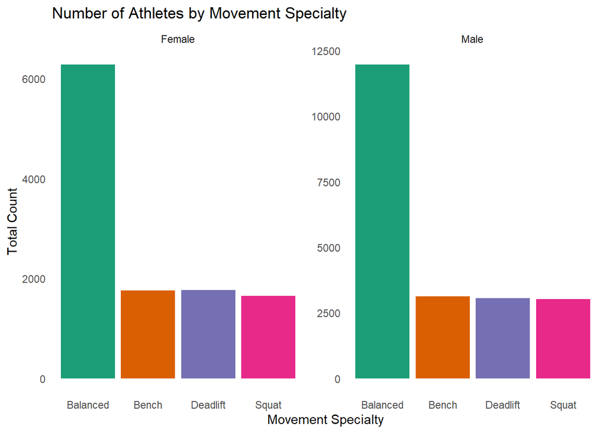

```r
# Male

overall_summary_male <- ipf_male_data_clean %>%
  summarise(
    Squat = sum(SquatSpecialist, na.rm = TRUE),
    Bench = sum(BenchSpecialist, na.rm = TRUE),
    Deadlift = sum(DeadliftSpecialist, na.rm = TRUE),
    Balanced = sum(BalancedSpecialist, na.rm = TRUE)
  ) %>%
  mutate(Sex = "Male")


# Female

overall_summary_female <- ipf_female_data_clean %>%
  summarise(
    Squat = sum(SquatSpecialist, na.rm = TRUE),
    Bench = sum(BenchSpecialist, na.rm = TRUE),
    Deadlift = sum(DeadliftSpecialist, na.rm = TRUE),
    Balanced = sum(BalancedSpecialist, na.rm = TRUE)
  ) %>%
  mutate(Sex = "Female")


overall_combined_summary <- bind_rows(overall_summary_male, overall_summary_female)


overall_combined_long <- overall_combined_summary %>%
  pivot_longer(cols = c(Squat, Bench, Deadlift, Balanced),
               names_to = "Metric", values_to = "Value")


ggplot(overall_combined_long, aes(x = Metric, y = Value, fill = Metric)) +
  geom_bar(stat = "identity", position = "dodge") +
  facet_wrap(~Sex, scales = "free_y") +
  labs(title = "Number of Athletes by Movement Specialty",
       x = "Movement Specialty",
       y = "Total Count") +
  theme_minimal() +
  scale_fill_brewer(palette = "Dark2") +
  theme(
    legend.position = "none",
    panel.grid.major = element_blank(),
    panel.grid.minor = element_blank(),
    panel.border = element_blank(),
  )
```

### 5.12. Number of athletes in the podiums by movement specialty.

As expected, **Balanced athletes** represent the majority of athletes who reach the podiums. Notice how **Deadlift Specialists** decrease in this graph compared to the last one.

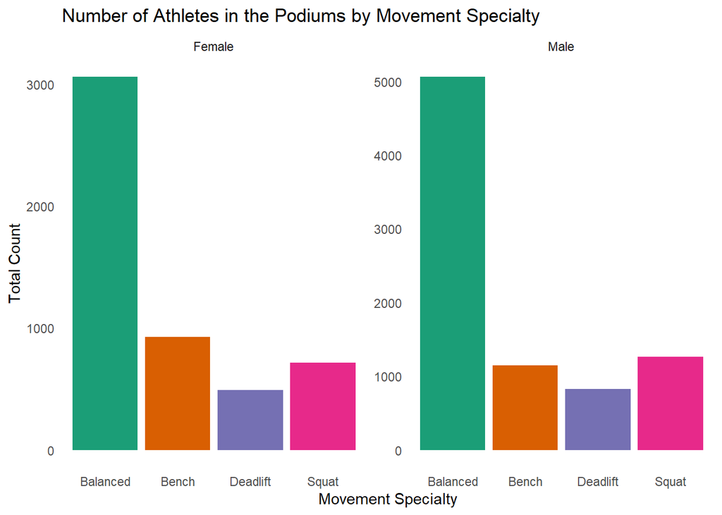

```r
# Male

podiums_summary_male <- podiums_specialty_male %>%
  summarise(
    Squat = sum(SQSpecialists, na.rm = TRUE),
    Bench = sum(BPSpecialists, na.rm = TRUE),
    Deadlift = sum(DLSpecialists, na.rm = TRUE),
    Balanced = sum(BalancedSpecialists, na.rm = TRUE)
  ) %>%
  mutate(Sex = "Male")


# Female

podiums_summary_female <- podiums_specialty_female %>%
  summarise(
    Squat = sum(SQSpecialists, na.rm = TRUE),
    Bench = sum(BPSpecialists, na.rm = TRUE),
    Deadlift = sum(DLSpecialists, na.rm = TRUE),
    Balanced = sum(BalancedSpecialists, na.rm = TRUE)
  ) %>%
  mutate(Sex = "Female")


podiums_combined_summary <- bind_rows(podiums_summary_male, podiums_summary_female)


podiums_combined_long <- podiums_combined_summary %>%
  pivot_longer(cols = c(Squat, Bench, Deadlift, Balanced),
               names_to = "Metric", values_to = "Value")


ggplot(podiums_combined_long, aes(x = Metric, y = Value, fill = Metric)) +
  geom_bar(stat = "identity", position = "dodge") +
  facet_wrap(~Sex, scales = "free_y") +
  labs(title = "Number of Athletes in the Podiums by Movement Specialty",
       x = "Movement Specialty",
       y = "Total Count") +
  theme_minimal() +
  scale_fill_brewer(palette = "Dark2") +
  theme(
    legend.position = "none",
    panel.grid.major = element_blank(),
    panel.grid.minor = element_blank(),
    panel.border = element_blank(),
  )
```

# 6. Conclusions

Clearly, the majority of athletes who reach the podiums are not **Deadlift Specialists**. In fact, compared to the overall count, they decrease. Therefore, the initial hypothesis is denied.

What if the **Proportions Model** could be used for further research?